# Philologie computationnelle - TP Chrétien

JBC & FC

2023-2024

```r
source("functions.R")
```

# Data

## Load texts

```r
data = t(as.matrix(read.csv("chrestien_fw_abs.csv", row.names = 1, header = TRUE)[, c(-1,-2)]))
auts = read.csv("chrestien_fw_abs.csv", row.names = 1, header = TRUE)[, 1]
data = data[rowSums(data) > 0,]
colnames(data) = gsub(pattern = "000", replacement = "k", colnames(data))
data_abs_save = data
```

## Features extraction, culling and selection

```r
# select = selection(data, z = 1.645)
# select = select[,4]
# # Get relative frequencies
# data_abs_save = data
# data = relativeFreqs(data)
# # keep only reliable features
# data = data[select,]
```

# Dimensionality reduction

Let’s use `FactoMineR`.

```r
# Load FactoMineR and factoextra for better visuals
library('FactoMineR')
library('factoextra')
```

```r
# And compute ACP. As the function expects individuals as lines and variables as columns, I'm transposing it
myCA = CA(t(data)[1:79,], graph = FALSE)
```

I can now look at the significance of my axes.

```r
myCA$eig
```

```
##          eigenvalue percentage of variance cumulative percentage of variance
## dim 1  0.0216368184              8.5698642                          8.569864
## dim 2  0.0166046192              6.5767216                         15.146586
## dim 3  0.0139160724              5.5118478                         20.658434
## dim 4  0.0102660639              4.0661604                         24.724594
## dim 5  0.0077787306              3.0809828                         27.805577
## dim 6  0.0072173837              2.8586457                         30.664223
## dim 7  0.0063110215              2.4996557                         33.163878
## dim 8  0.0062240192              2.4651961                         35.629074
## dim 9  0.0057194726              2.2653563                         37.894431
## dim 10 0.0053613494              2.1235117                         40.017942
## dim 11 0.0050022579              1.9812835                         41.999226
## dim 12 0.0048186474              1.9085595                         43.907785
## dim 13 0.0046388866              1.8373602                         45.745146
## dim 14 0.0045959744              1.8203636                         47.565509
## dim 15 0.0044201211              1.7507120                         49.316221
## dim 16 0.0043146564              1.7089398                         51.025161
## dim 17 0.0041727533              1.6527351                         52.677896
## dim 18 0.0041265838              1.6344484                         54.312344
## dim 19 0.0039568622              1.5672254                         55.879570
## dim 20 0.0038616606              1.5295182                         57.409088
## dim 21 0.0037799199              1.4971425                         58.906230
## dim 22 0.0035865143              1.4205388                         60.326769
## dim 23 0.0034955987              1.3845292                         61.711298
## dim 24 0.0034220312              1.3553907                         63.066689
## dim 25 0.0033203676              1.3151240                         64.381813
## dim 26 0.0031768907              1.2582960                         65.640109
## dim 27 0.0031200367              1.2357774                         66.875887
## dim 28 0.0030636935              1.2134611                         68.089348
## dim 29 0.0030045652              1.1900417                         69.279389
## dim 30 0.0028204293              1.1171095                         70.396499
## dim 31 0.0027476833              1.0882965                         71.484795
## dim 32 0.0027017449              1.0701013                         72.554897
## dim 33 0.0026058388              1.0321150                         73.587012
## dim 34 0.0025502981              1.0101166                         74.597128
## dim 35 0.0024935364              0.9876345                         75.584763
## dim 36 0.0024647323              0.9762258                         76.560989
## dim 37 0.0024161439              0.9569810                         77.517970
## dim 38 0.0023130170              0.9161348                         78.434104
## dim 39 0.0022966039              0.9096339                         79.343738
```

[output cut: 24 more lines]

```
## dim 64 0.0010564026              0.4184176                         95.604649
## dim 65 0.0010466251              0.4145450                         96.019194
## dim 66 0.0009796248              0.3880077                         96.407202
## dim 67 0.0009677434              0.3833017                         96.790504
## dim 68 0.0009120235              0.3612323                         97.151736
## dim 69 0.0008676085              0.3436405                         97.495377
## dim 70 0.0008408166              0.3330288                         97.828405
## dim 71 0.0008080430              0.3200479                         98.148453
## dim 72 0.0007803217              0.3090681                         98.457521
## dim 73 0.0007632162              0.3022930                         98.759815
## dim 74 0.0007047781              0.2791470                         99.038962
## dim 75 0.0006710316              0.2657807                         99.304742
## dim 76 0.0006142720              0.2432995                         99.548042
## dim 77 0.0005860199              0.2321095                         99.780151
## dim 78 0.0005550645              0.2198488                        100.000000
```

or plot it

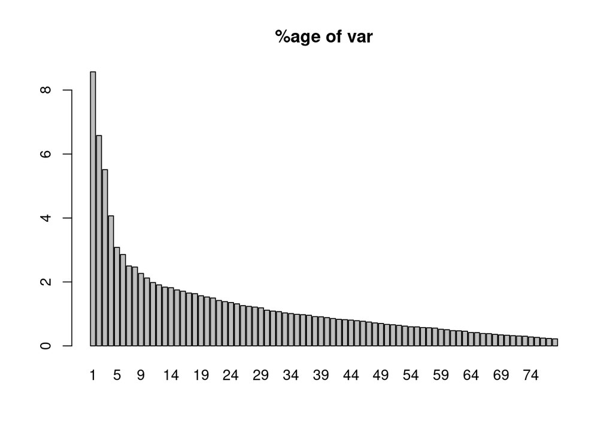

```r
barplot(myCA$eig[,2], main="%age of var", names.arg=1:nrow(myCA$eig))
```

Contribution:

```r
sort(myCA$col$contrib[,1], decreasing = TRUE)
```

```
##            je            le           vos           mon            ne
##  1.615921e+01  8.933089e+00  7.395664e+00  6.834900e+00  4.738901e+00
##            de           lor            ja            se        vostre
##  3.913434e+00  3.560978e+00  2.377325e+00  2.302046e+00  1.935862e+00
##            tu           qui            et           cel             a
##  1.816474e+00  1.623276e+00  1.560787e+00  1.479400e+00  1.301531e+00
##            mi           que        dusque           sor       chascun
##  1.254799e+00  1.252237e+00  1.235490e+00  1.138650e+00  1.119984e+00
##         maint          donc          rien          mais           par
##  9.851958e-01  9.689506e-01  9.567072e-01  9.302864e-01  8.026662e-01
##            il            un           ton         joste           son
##  7.519637e-01  7.157719e-01  7.092466e-01  6.761997e-01  5.961186e-01
##          mout            ci         nient          trop           las
##  5.931190e-01  5.575250e-01  5.108279e-01  5.080809e-01  5.038535e-01
##          tres           coi          quel        devers        encore
##  4.891818e-01  4.703406e-01  4.484381e-01  4.476847e-01  4.282005e-01
##         autel        defors         apres          mien           car
##  3.984280e-01  3.641907e-01  3.618329e-01  3.077652e-01  3.043391e-01
##        certes            or        espoir           mar      daerrain
##  2.904417e-01  2.882406e-01  2.778044e-01  2.752867e-01  2.741498e-01
##           ier          tant      ensement          cest           hai
##  2.587600e-01  2.480688e-01  2.406760e-01  2.355719e-01  2.150210e-01
##       derrier         parmi            on        devant        dedenz
##  2.135527e-01  2.132003e-01  2.123756e-01  2.040077e-01  2.007404e-01
##          main          fors           enz           nul         outre
##  1.941636e-01  1.931429e-01  1.869405e-01  1.844943e-01  1.809046e-01
##         encui       endroit           des       trestot           ore
##  1.799439e-01  1.736429e-01  1.692578e-01  1.633041e-01  1.527915e-01
##     premerain         entre          piec     autrement           pis
##  1.519508e-01  1.507673e-01  1.483817e-01  1.481913e-01  1.421892e-01
##         adonc           tel            ai      encontre        laienz
##  1.416629e-01  1.409767e-01  1.346311e-01  1.333408e-01  1.201727e-01
##            ha    quelconque      igaument         jehui         desor
##  1.114095e-01  1.109927e-01  1.109927e-01  1.098724e-01  1.098704e-01
##         entor           jus          icel        tempre          ades
##  1.084205e-01  1.084094e-01  1.077506e-01  1.031056e-01  1.020627e-01
##        aucant           non         ensus           sis          lues
##  1.017408e-01  1.008067e-01  1.004634e-01  9.892273e-02  9.623419e-02
##           soi       petitet        ersoir       aillors          itel
##  9.588019e-02  9.443397e-02  9.423743e-02  9.396588e-02  9.359493e-02
```

[output cut: 51 more lines]

```
##  3.528190e-03  3.492847e-03  3.205524e-03  2.926073e-03  2.571534e-03
##     entretant         itant        empres           ici       tantost
##  2.349249e-03  2.132577e-03  2.114943e-03  1.989343e-03  1.713705e-03
##          buer        manois         chies          foiz          sans
##  1.712492e-03  1.625663e-03  1.548670e-03  1.152168e-03  1.081585e-03
##      ensemble       dejoste         atant         ambes         jadis
##  1.072412e-03  9.218338e-04  8.715644e-04  4.850633e-04  4.257764e-04
##       travers         estre         aluec   dementieres          deca
##  3.493798e-04  2.467580e-04  2.359028e-04  2.218690e-04  2.091529e-04
##          naje        auques       tresque            si   franchement
##  8.524891e-05  7.996916e-05  7.412979e-05  7.269963e-05  6.479806e-05
##         desoz         assez         voire     contreval        plusor
##  6.070934e-05  5.406519e-05  5.251069e-05  8.326010e-06  2.958636e-06
##   sodainement
##  1.784145e-06
```

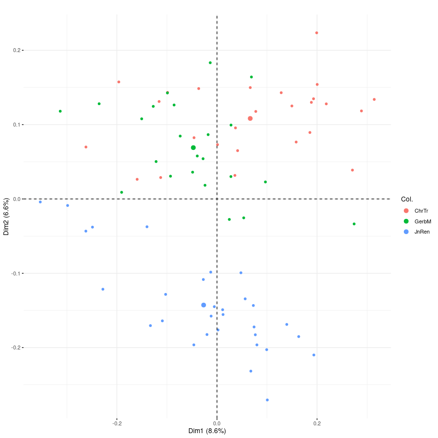

```r
#fviz_ca_row(myCA, geom=c("text"), labelsize=2)
fviz_ca_row(myCA, col.row = sub("\\_.*", "", rownames(myCA$row$coord)), title="", geom=c("point"), labelsize=2)
```

```r
#fviz_ca_col(myCA, col.col = sub("\\_.*", "", rownames(myCA$col$coord)), title="", geom=c("point", "text"), labelsize=2)
```

# Clustering

## Weighting

In oppositions to analyses like Correspondance analysis, that perform their own kind of ‘centering’ of the variables, here, we will do two types of normalisations:

- variables (rows) with z-scores;
- individuals (columns) with vector length normalisation (Euclidean norm).

```r
data = normalisations(data)
```

And let’s go.

## Clustering methods: hierarchical clustering

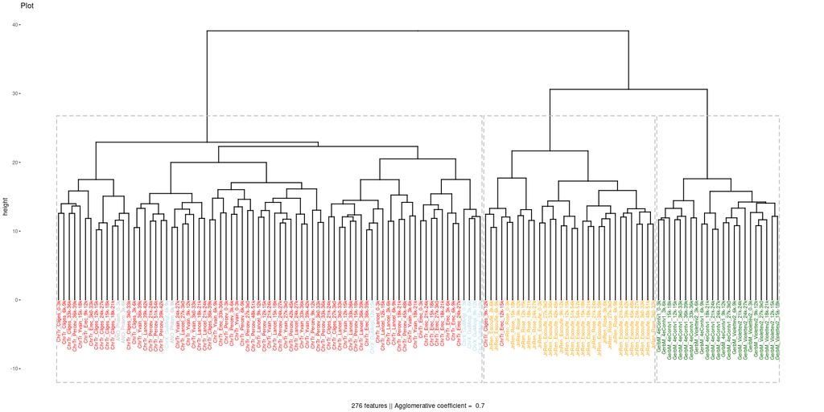

```r
library(cluster)
maCAH = agnes(t(data), metric = "manhattan", method="ward")
#plot(maCAH, which.plots = 2)
# Et une fonction un peu plus esthétique
maCAH_save = maCAH
cahPlotCol(maCAH, k = 3)
```

# Class description

### Creating groups: cutting an AHC

The number of classes should be chosen according to the dendrogram, and a height graph can be used (corresponding to the heights at which the branches of the dendrogram are separated).

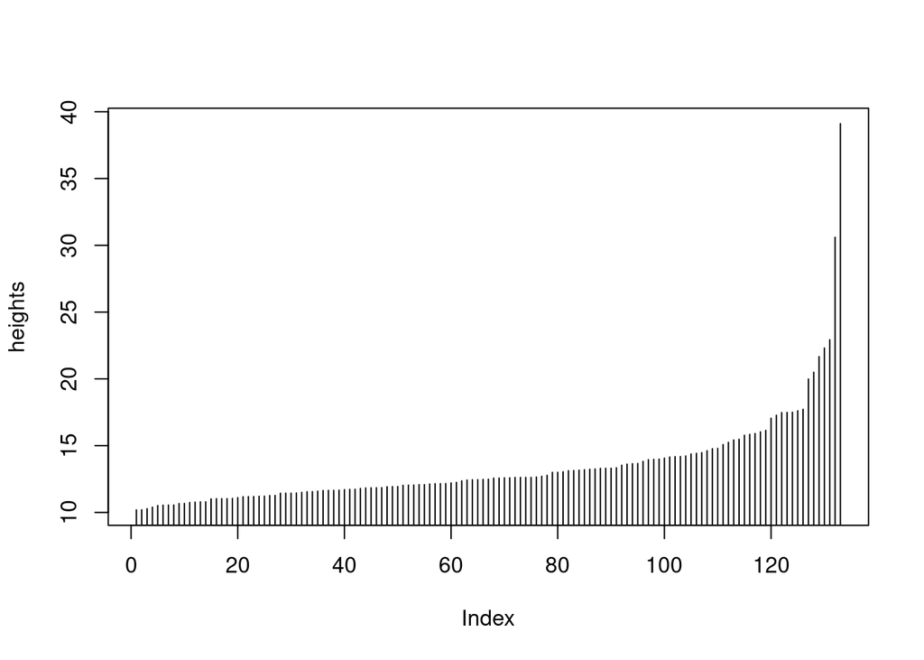

```r
maCAH = maCAH_save
maCAH2 = as.hclust(maCAH)
plot(maCAH2$height, type="h", ylab="heights")
```

```r
#cahPlotCol(maCAH, k = 4)
```

And let’s cut

```r
#Je découpe en classes
classes = cutree(maCAH, k = "3")
#J'ajoute les classes à mon tableau
myClassif = t(data)
myClassif = cbind(as.data.frame(myClassif), as.factor(classes))
colnames(myClassif[length(myClassif)])[] = "Classes"
```

```r
myClassif[length(myClassif)]
```

```
##                          as.factor(classes)
## ChrTr_Cliges_0-3k                         1
## ChrTr_Cliges_3k-6k                        1
## ChrTr_Cliges_6k-9k                        1
## ChrTr_Cliges_9k-12k                       2
## ChrTr_Cliges_12k-15k                      1
## ChrTr_Cliges_15k-18k                      1
## ChrTr_Cliges_18k-21k                      1
## ChrTr_Cliges_21k-24k                      1
## ChrTr_Cliges_24k-27k                      1
## ChrTr_Cliges_27k-3k0                      1
## ChrTr_Cliges_3k0-33k                      1
## ChrTr_Cliges_33k-36k                      1
## ChrTr_Cliges_36k-39k                      1
## ChrTr_Erec_0-3k                           1
## ChrTr_Erec_3k-6k                          1
## ChrTr_Erec_6k-9k                          1
## ChrTr_Erec_9k-12k                         1
## ChrTr_Erec_12k-15k                        2
## ChrTr_Erec_15k-18k                        1
## ChrTr_Erec_18k-21k                        1
## ChrTr_Erec_21k-24k                        1
## ChrTr_Erec_24k-27k                        1
## ChrTr_Erec_27k-3k0                        1
## ChrTr_Erec_3k0-33k                        1
## ChrTr_Erec_33k-36k                        1
## ChrTr_Erec_36k-39k                        1
## GerbM_4eContv1_0-3k                       3
## GerbM_4eContv1_3k-6k                      3
## GerbM_4eContv1_6k-9k                      3
## GerbM_4eContv1_9k-12k                     3
## GerbM_4eContv1_12k-15k                    3
## GerbM_4eContv1_15k-18k                    3
## GerbM_4eContv1_18k-21k                    3
## GerbM_4eContv1_21k-24k                    3
## GerbM_4eContv1_24k-27k                    3
## GerbM_4eContv1_27k-3k0                    3
## GerbM_4eContv1_3k0-33k                    3
## GerbM_4eContv1_33k-36k                    3
## GerbM_4eContv1_36k-39k                    3
```

[output cut: 80 more lines]

```
## ChrTr_Yvain_15k-18k                       1
## ChrTr_Yvain_18k-21k                       1
## ChrTr_Yvain_21k-24k                       1
## ChrTr_Yvain_24k-27k                       1
## ChrTr_Yvain_27k-3k0                       1
## ChrTr_Yvain_3k0-33k                       1
## ChrTr_Yvain_33k-36k                       1
## ChrTr_Yvain_36k-39k                       1
## ChrTr_Yvain_39k-42k                       1
## ChrX_GuillAngl_0-3k                       1
## ChrX_GuillAngl_3k-6k                      1
## ChrX_GuillAngl_6k-9k                      1
## ChrX_GuillAngl_9k-12k                     1
## ChrX_GuillAngl_12k-15k                    1
## ChrX_GuillAngl_15k-18k                    1
```

### Describing classes

Let’s do a v-test,

```r
#Je charge FactoMineR
library(FactoMineR)
#Et je décrit les classes
mesClasses = catdes(myClassif, num.var = length(myClassif))
# $\eta^2$
mesClasses$quanti.var[1:20,]
```

```
##               Eta2      P-value
## mi       0.6032768 5.022683e-27
## lues     0.4180558 3.978595e-16
## tres     0.3376199 1.916570e-12
## ainc     0.3365100 2.138705e-12
## ne       0.3113657 2.444871e-11
## puis     0.2983290 8.351135e-11
## envers   0.2916139 1.558427e-10
## i        0.2779403 5.451774e-10
## et       0.2724464 8.956873e-10
## piec     0.2663650 1.545051e-09
## par      0.2645165 1.821911e-09
## que      0.2616823 2.343876e-09
## ensement 0.2571425 3.501962e-09
## vos      0.2516564 5.670471e-09
## rien     0.2506545 6.189837e-09
## se       0.2267679 4.833874e-08
## mais     0.2248299 5.695124e-08
## poi      0.2232025 6.533746e-08
## jusque   0.2139341 1.420891e-07
## fi       0.2104829 1.893136e-07
```

```r
# v-test pour la classe 1
mesClasses$quanti$`2`
```

```
##               v.test Mean in category  Overall mean sd in category Overall sd
## lues        7.432426       0.07300456  7.760116e-05    0.090846838 0.06338088
## ainc        5.993744       0.05329410 -1.402815e-03    0.085818381 0.05894750
## piec        5.588973       0.05043315 -6.722174e-04    0.089631823 0.05906567
## ai          5.104455       0.04216336 -1.730094e-03    0.089897669 0.05554578
## son         4.762659       0.04414490 -2.930194e-04    0.048266300 0.06027052
## buer        4.483014       0.04465774  7.059136e-04    0.098141931 0.06332973
## de          4.342790       0.04317705  8.257859e-04    0.072617816 0.06299387
## e           4.205535       0.04049423 -2.356442e-04    0.101030083 0.06255939
## por         4.150096       0.03857561 -9.683274e-04    0.054023452 0.06154922
## or          4.018021       0.03830009  3.234897e-04    0.071409318 0.06105266
## orendroit   3.770621       0.03374446 -7.245119e-04    0.090464500 0.05904950
## huimais     3.757853       0.03611431 -2.655292e-05    0.091457791 0.06212400
## lor         3.656308       0.03547872  2.764698e-04    0.077611886 0.06219112
## cel         3.523703       0.03251869 -9.504197e-04    0.061729450 0.06135438
## sempre      3.516382       0.02851283 -9.845056e-04    0.105575048 0.05418604
## a           3.473814       0.03246850  3.823202e-04    0.058955505 0.05966397
## jadis       3.356658       0.03305330  2.907956e-04    0.090910368 0.06304791
## par         3.342869       0.03234775 -3.183964e-04    0.054456069 0.06312179
## o           3.337712       0.03305395  5.699007e-04    0.072297592 0.06286689
## cest        3.195129       0.03053971  1.484300e-04    0.071006305 0.06144143
## tel         3.033653       0.02699545 -1.361219e-03    0.059204659 0.06037957
## on          3.026679       0.03019895  7.613598e-04    0.060873332 0.06282559
## le          2.977872       0.02776694 -1.687586e-04    0.059276894 0.06059744
## matin       2.971334       0.02901206  5.040591e-04    0.081157651 0.06197494
## ou          2.936827       0.02769194 -2.386716e-04    0.058966796 0.06143316
## encore      2.814237       0.02792735  1.012135e-03    0.079349141 0.06177857
## non         2.725671       0.02567863  2.777969e-05    0.063093810 0.06078955
## auques      2.719138       0.02593740  2.001416e-04    0.081334333 0.06114088
## il          2.641227       0.02547260  5.509920e-05    0.064368290 0.06216239
## entor       2.618108       0.02426345 -2.773734e-04    0.070551788 0.06054834
## ome         2.574238       0.02620167  1.357601e-03    0.075951036 0.06234115
## ce          2.559692       0.02304635 -5.938111e-04    0.064138103 0.05965727
## el          2.548908       0.02481374  3.912810e-04    0.078035328 0.06189220
## iluec       2.542842       0.02304613 -6.313230e-04    0.066460405 0.06014732
## comfait     2.536353       0.01980304 -1.068248e-03    0.106093619 0.05315453
## las         2.532571       0.02234792 -1.272078e-03    0.082206145 0.06024471
## chascun     2.430028       0.02171688 -9.237044e-04    0.049632629 0.06018344
## ariere      2.428010       0.02284947 -2.840075e-04    0.063950565 0.06154476
## estre       2.427895       0.02253748 -3.262122e-04    0.053912271 0.06082990
```

[output cut: 119 more lines]

```
## ci         1.467646e-03
## mien       1.418753e-03
## mie        1.368095e-03
## neporcant  1.244184e-03
## ton        1.126102e-03
## ne         1.073424e-03
## se         1.421983e-04
## tu         6.452572e-05
## si         5.064775e-05
## trestot    1.342970e-05
## et         6.152565e-07
## maintenant 4.373117e-07
## tantost    3.412089e-07
## vos        1.148049e-07
## mais       4.553490e-08
```

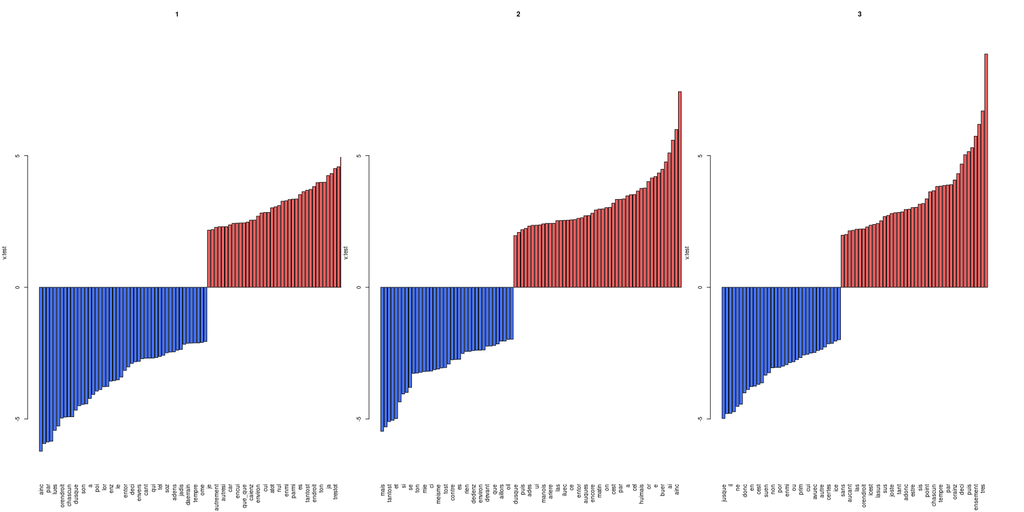

```r
plot(mesClasses, level = 0.01, barplot = TRUE)
```

```r
classesDesc(maCAH, data, k = 3)
```

```
##
## Link between the cluster variable and the quantitative variables
## ================================================================
##                  Eta2      P-value
## mi         0.60327683 5.022683e-27
## lues       0.41805577 3.978595e-16
## tres       0.33761994 1.916570e-12
## ainc       0.33651002 2.138705e-12
## ne         0.31136572 2.444871e-11
## puis       0.29832901 8.351135e-11
## envers     0.29161391 1.558427e-10
## i          0.27794032 5.451774e-10
## et         0.27244642 8.956873e-10
## piec       0.26636500 1.545051e-09
## par        0.26451650 1.821911e-09
## que        0.26168230 2.343876e-09
## ensement   0.25714249 3.501962e-09
## vos        0.25165639 5.670471e-09
## rien       0.25065446 6.189837e-09
## se         0.22676794 4.833874e-08
## mais       0.22482993 5.695124e-08
## poi        0.22320250 6.533746e-08
## jusque     0.21393412 1.420891e-07
## fi         0.21048288 1.893136e-07
## maint      0.19820508 5.201711e-07
## enz        0.19779699 5.377998e-07
## maintenant 0.19680416 5.831831e-07
## tantost    0.19644731 6.004000e-07
## ai         0.19590878 6.273334e-07
## chascun    0.19234613 8.380224e-07
## son        0.19201155 8.610682e-07
## tu         0.18950339 1.054882e-06
## il         0.18857588 1.136942e-06
## orendroit  0.18818591 1.173292e-06
## dusque     0.18250007 1.853301e-06
## donc       0.18210942 1.912211e-06
## trestot    0.17710015 2.852510e-06
## de         0.17611780 3.084363e-06
## deci       0.16606705 6.824790e-06
## por        0.16122708 9.970297e-06
```

[output cut: 602 more lines]

```
## non       2.229542e-03
## parmi     1.172288e-03
## suen      8.467133e-04
## o         2.839795e-04
## cest      2.276863e-04
## ja        1.739781e-04
## en        1.617304e-04
## come      1.022307e-04
## donc      6.032656e-05
## rien      9.038997e-06
## ne        6.036687e-06
## que       2.284464e-06
## il        1.686762e-06
## i         1.615036e-06
## jusque    6.383953e-07
```

It is also possible to use other computations of specificities, like Lafon (1984), that needs absolute frequencies.

```r
# install.packages("textometry")
freq_abs = data_abs_save
# On splitte le corpus selon les classes
freq_abs_class = matrix(nrow = nrow(freq_abs), ncol = length(unique(classes)), dimnames = list(rownames(freq_abs), unique(classes)))
for(i in 1:length(unique(classes))){
  # sum the values for each member of the class
  freq_abs_class[, i] = rowSums(freq_abs[, classes == i])
}
specs = textometry::specificities(freq_abs_class)
# and now we can look at the specificities for class 1
# positive or negative
head(sort(specs[, 2], decreasing = TRUE))
```

```
##    lues     son      de      le    ainc     lor
## 30.2813 21.1948 17.2596 14.2810 13.7955 12.3013
```

```r
head(sort(specs[, 2]))
```

```
##         tu        vos         et       mais    tantost maintenant
##   -68.1375   -61.7646   -24.2918   -20.0398   -14.2268   -13.7055
```

And one can use other varieties of non-parametric tests, such as the Mann-Whitney test, for example, to compare two populations…